# UW 350: HW1

### Histogram of Heating Load

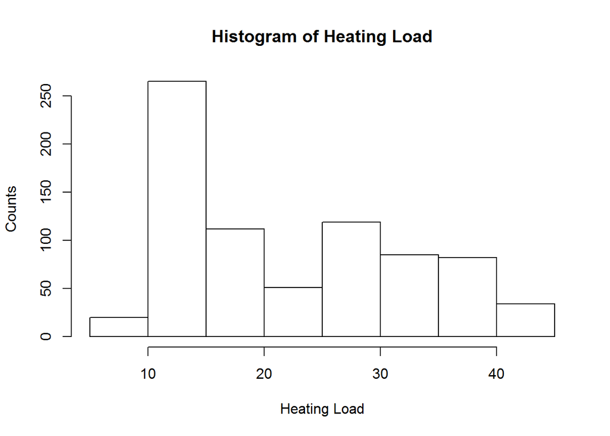

```r
  hist(energy$Heating.Load, main = paste("Histogram of Heating Load"), xlab = "Heating Load", ylab = "Counts")
```

The Heating load varies from 0 to 50 units as well. Maximum counts for heating load is in the range [10-15] units with 250+ counts.

### Histogram of Relative Compactness

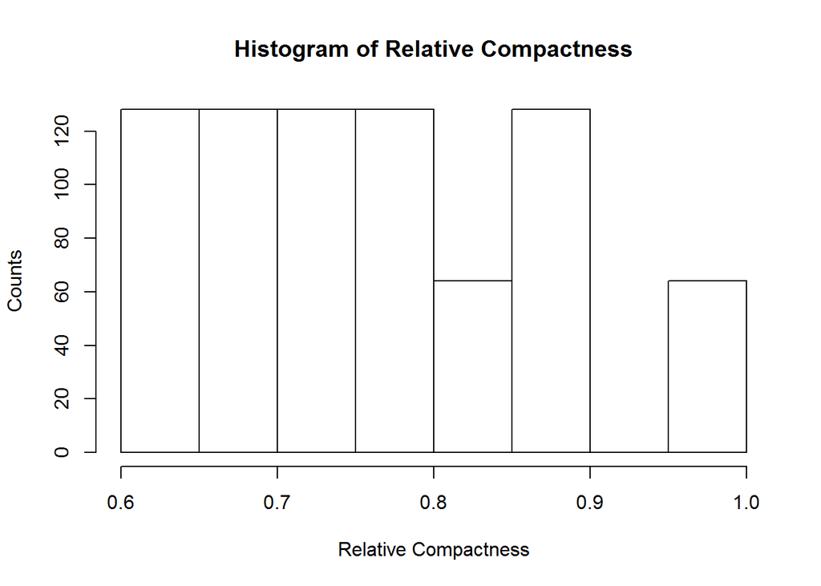

```r
  hist(energy$Relative.Compactness, main = paste("Histogram of Relative Compactness"), xlab = "Relative Compactness", ylab = "Counts")
```

Relative Compactness measure varies from 0.6 units to 1.0 units. Number of counts in each bin of the Relative Compactness measure is fairly similar i.e Most of the bins have about 125 counts and 2 remainng bins have a count of 60

### Histogram of Surface Area

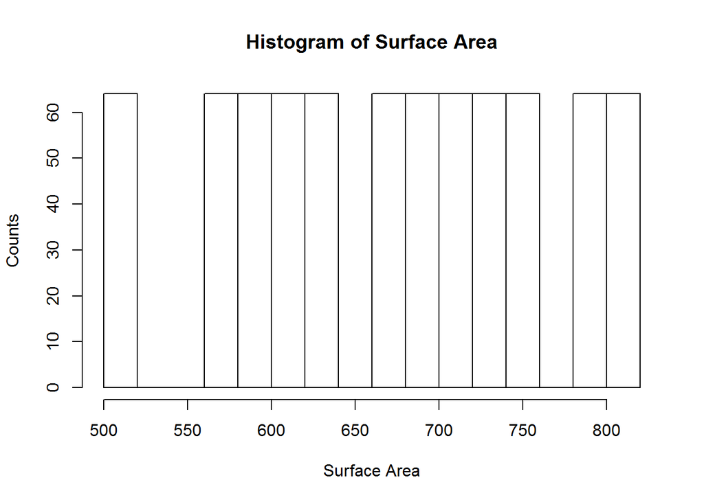

```r
  hist(energy$Surface.Area, main = paste("Histogram of Surface Area"), xlab = "Surface Area", ylab = "Counts")
```

Surface Area measures from 500 to 820 Units. The counts for most of the bins are equal with each bin having about 70 entries

### Histogram of Wall Area

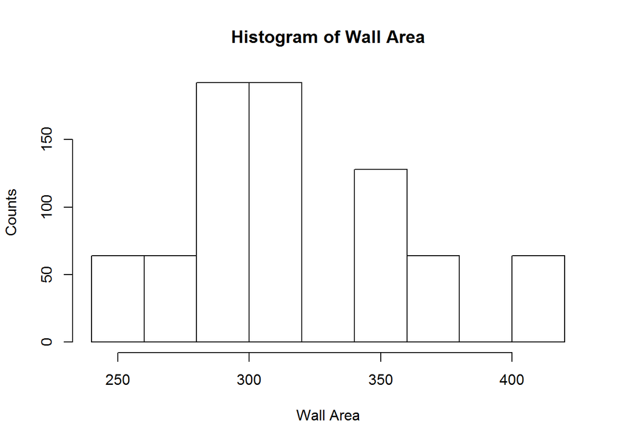

```r
  hist(energy$Wall.Area, main = paste("Histogram of Wall Area"), xlab = "Wall Area", ylab = "Counts")
```